# KNN

#Información preliminar#

Para este ejercicio, usaremos el paquete caret para hacer el modelado y la predicción de kNN, el paquete pander para poder generar tablas bien formadas y el doMC para aprovechar el procesamiento paralelo con múltiples núcleos. Además, definiremos algunas funciones de utilidad para simplificar asuntos más adelante en el código.

```r
uciurl <- "https://archive.ics.uci.edu/ml/machine-learning-databases/breast-cancer-wisconsin/wdbc.data"
download.file(url=uciurl, destfile="wdbc.data", method="curl")
```

[output not shown]

```r
wdbc <- read.csv("wdbc.data", header=FALSE, stringsAsFactors=FALSE)[-1]
wdbc <- wdbc[sample(nrow(wdbc)),]
features <- c("radius", "texture", "perimeter", "area", "smoothness",
              "compactness", "concavity", "concave_points", "symmetry",
              "fractal_dimension")
calcs <- c("mean", "se", "worst")
colnames(wdbc) <- c("diagnosis",
                    paste0(rep(features, 3), "_", rep(calcs, each=10)))
```

```r
#install.packages("doMC", repos="http://R-Forge.R-project.org")

library(ggplot2)
library(caret)
library(pander)

require(doMC)

#library(doMC)

registerDoMC(cores=4)

# una función de utilidad para tablas% freq
frqtab <- function(x, caption) {
    round(100*prop.table(table(x)), 1)
}

# función de utilidad para redondear los valores en una lista
# pero solo si son numéricos
round_numeric <- function(lst, decimals=2) {
    lapply(lst, function(x) {
        if (is.numeric(x)) {
            x <- round(x, decimals)
        }
        x
        })
}

# función de utilidad para resumir los resultados de comparación del modelo
summod <- function(cm, fit) {
    summ <- list(k=fit$finalModel$k,
                 metric=fit$metric,
                 value=fit$results[fit$results$k == fit$finalModel$k, fit$metric],
                 TN=cm$table[1,1],  # verdaderos negativos
                 TP=cm$table[2,2],  # verdaderos positivos
                 FN=cm$table[1,2],  # falsos negativos
                 FP=cm$table[2,1],  # falsos positivos
                 acc=cm$overall["Accuracy"],  # exactitud
                 sens=cm$byClass["Sensitivity"],  # sensibilidad
                 spec=cm$byClass["Specificity"],  # especificidad
                 PPV=cm$byClass["Pos Pred Value"], # valor predictivo positivo
                 NPV=cm$byClass["Neg Pred Value"]) # nevalor predictivo negativo
    round_numeric(summ)
}
```

#Lectura y preparación de los datos.#

Como la primera columna en el archivo CSV original contiene solo una identificación, que no usaremos, leemos el csv y lo eliminamos antes de asignarlo a un marco de datos.

Además, convertiremos el diagnóstico en un factor, de manera similar al ejemplo del libro.

```r
# Recodificar el diagnóstico como un factor, como se hace en el ejemplo del libro.

wdbc$diagnosis <- factor(wdbc$diagnosis, levels = c("B", "M"),
                         labels = c("Benigno", "Maligno"))
str(wdbc)
```

```
'data.frame':   569 obs. of  31 variables:
 $ diagnosis              : Factor w/ 2 levels "Benigno","Maligno": 1 2 2 2 1 2 1 1 1 1 ...
 $ radius_mean            : num  12.6 16.3 23.2 17.6 10.1 ...
 $ texture_mean           : num  24 20.7 27 15.1 17.5 ...
 $ perimeter_mean         : num  81.3 106.9 153.5 115 64.4 ...
 $ area_mean              : num  496 814 1670 955 311 ...
 $ smoothness_mean        : num  0.079 0.1169 0.0951 0.0985 0.1007 ...
 $ compactness_mean       : num  0.0753 0.1319 0.1682 0.1157 0.0733 ...
 $ concavity_mean         : num  0.0544 0.1478 0.195 0.0988 0.0251 ...
 $ concave_points_mean    : num  0.0204 0.0849 0.1237 0.0795 0.0177 ...
 $ symmetry_mean          : num  0.151 0.195 0.191 0.174 0.189 ...
 $ fractal_dimension_mean : num  0.0602 0.0628 0.0631 0.0615 0.0633 ...
 $ radius_se              : num  0.245 0.438 1.058 0.6 0.262 ...
 $ texture_se             : num  1.066 1.232 0.964 0.823 2.015 ...
 $ perimeter_se           : num  1.45 3.27 7.25 4.66 1.78 ...
```

[output cut: 17 more lines]

Solo para tener una medida base, echemos un vistazo a las frecuencias para el diagnóstico

```r
library(pander)

ft_orig <- frqtab(wdbc$diagnosis)
pander(ft_orig, style="rmarkdown", caption="Frecuencias de diagnostico originales (%)")
```

```
| Benigno | Maligno |
|:-------:|:-------:|
|  62.7   |  37.3   |

Table: Frecuencias de diagnostico originales (%)
```

#Usando la precisión como métrica#

En el libro, las primeras 469 filas se asignan al conjunto de entrenamiento, y el resto al conjunto de prueba (Nota: estoy usando el conjunto de datos modificado del libro, si uso los datos originales de UCI, sus resultados podrían ser diferentes)

```r
wdbc_train <- wdbc[1:469,]
wdbc_test <- wdbc[470:569,]
```

Solo para completar, verifiquemos si esa estrategia de partición de datos nos brinda conjuntos con distribuciones similares a las de los datos originales.

```r
ft_train <- frqtab(wdbc_train$diagnosis)
ft_test <- frqtab(wdbc_test$diagnosis)
ftcmp_df <- as.data.frame(cbind(ft_orig, ft_train, ft_test))
colnames(ftcmp_df) <- c("Original", "Set entrenamiento", "Set prueba")
pander(ftcmp_df, style="rmarkdown",
             caption="Comparación de frecuencias de diagnóstico (en%)")
```

```
|   &nbsp;    | Original | Set entrenamiento | Set prueba |
|:-----------:|:--------:|:-----------------:|:----------:|
| **Benigno** |   62.7   |       61.4        |     69     |
| **Maligno** |   37.3   |       38.6        |     31     |

Table: Comparación de frecuencias de diagnóstico (en%)
```

A pesar de esta disparidad, intentemos utilizar kNN5 en los conjuntos. Usaremos la validación cruzada repetida y escalaremos los datos utilizando el método de rango.

El ejemplo en el libro hace el modelado en varios valores discretos de k, aquí caret proporciona los medios para hacer esa optimización automáticamente utilizando una métrica de selección para decidir qué modelo es óptimo. Usaremos la precisión como la métrica.

```r
library(e1071)
ctrl <- trainControl(method="repeatedcv", number=10, repeats=3)
set.seed(12345)
knnFit1 <- train(diagnosis ~ ., data=wdbc_train, method="knn",
                trControl=ctrl, metric="Accuracy", tuneLength=20,
                preProc=c("range"))
knnFit1
```

```
k-Nearest Neighbors

469 samples
 30 predictor
  2 classes: 'Benigno', 'Maligno'

Pre-processing: re-scaling to [0, 1] (30)
Resampling: Cross-Validated (10 fold, repeated 3 times)
Summary of sample sizes: 422, 423, 422, 422, 422, 423, ...
Resampling results across tuning parameters:

  k   Accuracy   Kappa
   5  0.9680665  0.9321834
   7  0.9687763  0.9336649
   9  0.9673573  0.9304216
  11  0.9652148  0.9256071
  13  0.9673271  0.9301425
  15  0.9680369  0.9314651
  17  0.9673418  0.9299677
  19  0.9630705  0.9206875
  21  0.9637495  0.9221061
  23  0.9595546  0.9131216
  25  0.9574115  0.9083170
  27  0.9573961  0.9081718
  29  0.9566862  0.9066939
  31  0.9538641  0.9008308
  33  0.9531549  0.8991912
  35  0.9524457  0.8975734
  37  0.9524155  0.8974120
  39  0.9517210  0.8959739
  41  0.9531395  0.8989734
  43  0.9517210  0.8959721

Accuracy was used to select the optimal model using the largest value.
The final value used for the model was k = 7.
```

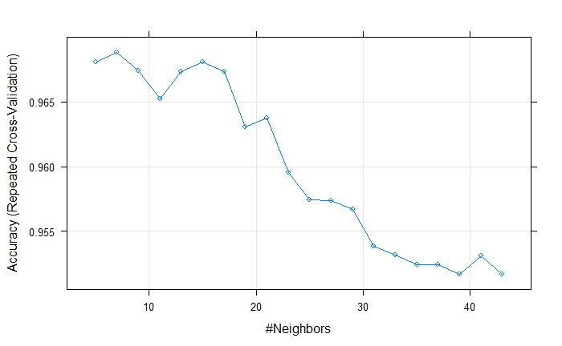

```r
plot(knnFit1)
```

Usemos este modelo para predecir el diagnóstico en el conjunto de pruebas y luego calculemos la matriz de confusión correspondiente:

```r
knnPredict1 <- predict(knnFit1, newdata=wdbc_test)
cmat1 <- confusionMatrix(knnPredict1, wdbc_test$diagnosis, positive="Maligno")
cmat1
```

```
Confusion Matrix and Statistics

          Reference
Prediction Benigno Maligno
   Benigno      68       3
   Maligno       1      28

               Accuracy : 0.96
                 95% CI : (0.9007, 0.989)
    No Information Rate : 0.69
    P-Value [Acc > NIR] : 1.346e-11

                  Kappa : 0.9048

 Mcnemar's Test P-Value : 0.6171

            Sensitivity : 0.9032
            Specificity : 0.9855
         Pos Pred Value : 0.9655
         Neg Pred Value : 0.9577
             Prevalence : 0.3100
         Detection Rate : 0.2800
   Detection Prevalence : 0.2900
      Balanced Accuracy : 0.9444

       'Positive' Class : Maligno
```

#Usando kappa como métrica# Averigüemos si el modelo cambia si usamos la misma partición de datos, pero esta vez usamos kappa como la métrica de selección del modelo.

```r
knnFit2 <- train(diagnosis ~ ., data=wdbc_train, method="knn",
                trControl=ctrl, metric="Kappa", tuneLength=20,
                preProc=c("range"))
knnFit2
```

```
k-Nearest Neighbors

469 samples
 30 predictor
  2 classes: 'Benigno', 'Maligno'

Pre-processing: re-scaling to [0, 1] (30)
Resampling: Cross-Validated (10 fold, repeated 3 times)
Summary of sample sizes: 422, 422, 423, 422, 422, 422, ...
Resampling results across tuning parameters:

  k   Accuracy   Kappa
   5  0.9701196  0.9363941
   7  0.9686858  0.9332419
   9  0.9665575  0.9283962
  11  0.9679611  0.9309856
  13  0.9679618  0.9309531
  15  0.9657879  0.9258502
  17  0.9636910  0.9216512
  19  0.9622572  0.9187359
  21  0.9601295  0.9137572
  23  0.9551187  0.9028571
  25  0.9558427  0.9047060
  27  0.9565674  0.9061794
  29  0.9558279  0.9046553
  31  0.9537003  0.9001198
  33  0.9515874  0.8955053
  35  0.9530065  0.8983795
  37  0.9523120  0.8969126
  39  0.9515874  0.8953766
  41  0.9508929  0.8939380
  43  0.9516022  0.8952655

Kappa was used to select the optimal model using the largest value.
The final value used for the model was k = 5.
```

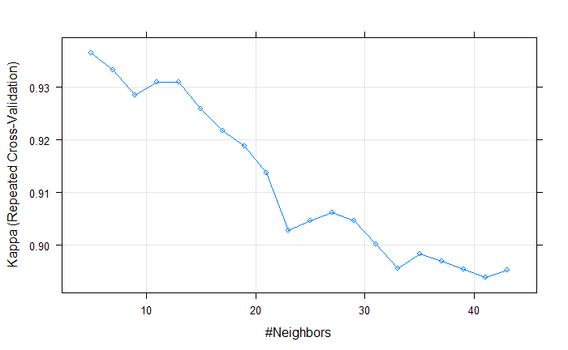

```r
plot(knnFit2)
```

```r
knnPredict2 <- predict(knnFit2, newdata=wdbc_test)
cmat2 <- confusionMatrix(knnPredict2, wdbc_test$diagnosis, positive="Maligno")
cmat2
```

```
Confusion Matrix and Statistics

          Reference
Prediction Benigno Maligno
   Benigno      68       2
   Maligno       1      29

               Accuracy : 0.97
                 95% CI : (0.9148, 0.9938)
    No Information Rate : 0.69
    P-Value [Acc > NIR] : 1.205e-12

                  Kappa : 0.9292

 Mcnemar's Test P-Value : 1

            Sensitivity : 0.9355
            Specificity : 0.9855
         Pos Pred Value : 0.9667
         Neg Pred Value : 0.9714
             Prevalence : 0.3100
         Detection Rate : 0.2900
   Detection Prevalence : 0.3000
      Balanced Accuracy : 0.9605

       'Positive' Class : Maligno
```

#Usando ROC como métrica#

Finalmente, consideremos usar la métrica ROC, para eso necesitamos cambiar los parámetros de control:

```r
ctrl <- trainControl(method="repeatedcv", number=10, repeats=3,
                     classProbs=TRUE, summaryFunction=twoClassSummary)
knnFit3 <- train(diagnosis ~ ., data=wdbc_train, method="knn",
                trControl=ctrl, metric="ROC", tuneLength=30,
                preProc=c("range"))
knnFit3
```

```
k-Nearest Neighbors

469 samples
 30 predictor
  2 classes: 'Benigno', 'Maligno'

Pre-processing: re-scaling to [0, 1] (30)
Resampling: Cross-Validated (10 fold, repeated 3 times)
Summary of sample sizes: 422, 423, 422, 422, 422, 423, ...
Resampling results across tuning parameters:

  k   ROC        Sens       Spec
   5  0.9887123  0.9837849  0.9411306
   7  0.9919621  0.9895320  0.9483431
   9  0.9919872  0.9895731  0.9427875
```

[output cut: 30 more lines]

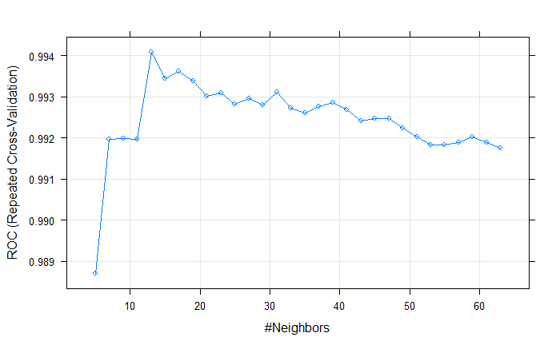

```r
plot(knnFit3)
```

```r
knnPredict3 <- predict(knnFit3, newdata=wdbc_test)
cmat3 <- confusionMatrix(knnPredict3, wdbc_test$diagnosis, positive="Maligno")
cmat3
```

```
Confusion Matrix and Statistics

          Reference
Prediction Benigno Maligno
   Benigno      69       2
   Maligno       0      29

               Accuracy : 0.98
                 95% CI : (0.9296, 0.9976)
    No Information Rate : 0.69
    P-Value [Acc > NIR] : 8.018e-14

                  Kappa : 0.9524

 Mcnemar's Test P-Value : 0.4795

            Sensitivity : 0.9355
            Specificity : 1.0000
         Pos Pred Value : 1.0000
         Neg Pred Value : 0.9718
             Prevalence : 0.3100
         Detection Rate : 0.2900
   Detection Prevalence : 0.2900
      Balanced Accuracy : 0.9677

       'Positive' Class : Maligno
```

#Comparando los tres modelos.#

Solo para tener una comprensión clara de las diferencias entre los tres modelos de kNN, los resumiremos en una tabla. También incluiremos los datos del ejemplo del libro.

```r
tn=61
tp=37
fn=2
fp=0
book_example <- list(
    k=21,
    metric=NA,
    value=NA,
    TN=tn,
    TP=tp,
    FN=fn,
    FP=fp,
    acc=(tp + tn)/(tp + tn + fp + fn),
    sens=tp/(tp + fn),
    spec=tn/(tn + fp),
    PPV=tp/(tp + fp),
    NPV=tn/(tn + fn))

model_comp <- as.data.frame(
    rbind(round_numeric(book_example),
          summod(cmat1, knnFit1),
          summod(cmat2, knnFit2),
          summod(cmat3, knnFit3)))
rownames(model_comp) <- c("Book model", "Model 1", "Model 2", "Model 3")
pander(model_comp[,-3], split.tables=Inf, keep.trailing.zeros=TRUE,
       style="rmarkdown",
       caption="Resultados del modelo al comparar predicciones y conjunto de pruebas")
```

```
|     &nbsp;     | k  |  metric  | TN | TP | FN | FP | acc  | sens | spec | PPV  | NPV  |
|:--------------:|:--:|:--------:|:--:|:--:|:--:|:--:|:----:|:----:|:----:|:----:|:----:|
| **Book model** | 21 |    NA    | 61 | 37 | 2  | 0  | 0.98 | 0.95 |  1   |  1   | 0.97 |
|  **Model 1**   | 7  | Accuracy | 68 | 28 | 3  | 1  | 0.96 | 0.9  | 0.99 | 0.97 | 0.96 |
|  **Model 2**   | 5  |  Kappa   | 68 | 29 | 2  | 1  | 0.97 | 0.94 | 0.99 | 0.97 | 0.97 |
|  **Model 3**   | 13 |   ROC    | 69 | 29 | 2  | 0  | 0.98 | 0.94 |  1   |  1   | 0.97 |

Table: Resultados del modelo al comparar predicciones y conjunto de pruebas
```

El modelo del libro que usa 21 vecinos es un poco mejor en precisión, sensibilidad y VAN. Por lo tanto, tiende a cometer menos errores de Tipo II que los otros modelos. Por otro lado, utiliza casi el doble de vecinos que cualquiera de los modelos estimados utilizando caret.

#Cambiando la estrategia de partición de datos# Una pregunta sigue siendo si una estrategia de partición diferente mejorará o no los modelos de intercalación. Así que probaremos tres estrategias de partición de datos diferentes utilizando la métrica de precisión.

Elegiremos las siguientes particiones de datos (proporción de entrenamiento: casos de prueba):

Modelo A: 469: 100 (la proporción utilizada en el libro) Modelo B: 1: 1 (50% de entrenamiento, 50% de prueba) Modelo C: 9: 1 (90% de entrenamiento, 10% de prueba)

#Usando las proporciones del libro.# Usaremos la proporción de 469: 100 para dividir los datos (~ 82.425% de las filas para entrenamiento) tratando de mantener las proporciones de diagnóstico similares en todos los conjuntos. Para mostrar que esta última condición se mantiene, compararemos las proporciones de diagnóstico en los conjuntos de datos originales, de entrenamiento y de prueba.

```r
set.seed(12345)
ptr <- 469/569
train_index <- createDataPartition(wdbc$diagnosis, p=ptr, list=FALSE)
wdbc_train <- wdbc[train_index,]
wdbc_test <- wdbc[-train_index,]
ft_train <- frqtab(wdbc_train$diagnosis)
ft_test <- frqtab(wdbc_test$diagnosis)
ft_df <- as.data.frame(cbind(ft_orig, ft_train, ft_test))
colnames(ft_df) <- c("Original", "Training set", "Test set")
pander(ft_df, style="rmarkdown",
       caption=paste0("Comparison of diagnosis frequencies for prop(train)=",
                      round(ptr*100, 2),"%"))
```

```
|   &nbsp;    | Original | Training set | Test set |
|:-----------:|:--------:|:------------:|:--------:|
| **Benigno** |   62.7   |     62.8     |   62.6   |
| **Maligno** |   37.3   |     37.2     |   37.4   |

Table: Comparison of diagnosis frequencies for prop(train)=82.43%
```

Ahora calculemos el modelo usando Precisión como métrica de selección:

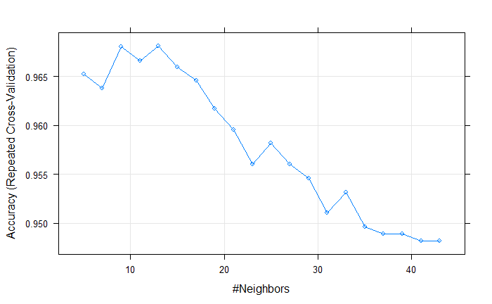

```r
ctrl <- trainControl(method="repeatedcv", number=10, repeats=3)
set.seed(12345)
knnFitA <- train(diagnosis ~ ., data=wdbc_train, method="knn",
                trControl=ctrl, metric="Accuracy", tuneLength=20,
                preProc=c("range"))
plot(knnFitA)
```

```r
knnPredictA <- predict(knnFitA, newdata=wdbc_test)
cmatA <- confusionMatrix(knnPredictA, wdbc_test$diagnosis, positive="Maligno")
cmatA
```

```
Confusion Matrix and Statistics

          Reference
Prediction Benigno Maligno
   Benigno      62       2
   Maligno       0      35

               Accuracy : 0.9798
                 95% CI : (0.9289, 0.9975)
    No Information Rate : 0.6263
    P-Value [Acc > NIR] : <2e-16

                  Kappa : 0.9564

 Mcnemar's Test P-Value : 0.4795

            Sensitivity : 0.9459
            Specificity : 1.0000
         Pos Pred Value : 1.0000
         Neg Pred Value : 0.9688
             Prevalence : 0.3737
         Detection Rate : 0.3535
   Detection Prevalence : 0.3535
      Balanced Accuracy : 0.9730

       'Positive' Class : Maligno
```

#Usando el entrenamiento 1: 1: proporción de prueba#

```r
set.seed(12345)
ptr <- .5
train_index <- createDataPartition(wdbc$diagnosis, p=ptr, list=FALSE)
wdbc_train <- wdbc[train_index,]
wdbc_test <- wdbc[-train_index,]
set.seed(12345)
knnFitB <- train(diagnosis ~ ., data=wdbc_train, method="knn",
                trControl=ctrl, metric="Accuracy", tuneLength=20,
                preProc=c("range"))
knnPredictB <- predict(knnFitB, newdata=wdbc_test)
cmatB <- confusionMatrix(knnPredictB, wdbc_test$diagnosis, positive="Maligno")
cmatB
```

```
Confusion Matrix and Statistics

          Reference
Prediction Benigno Maligno
   Benigno     175       8
   Maligno       3      98

               Accuracy : 0.9613
                 95% CI : (0.9318, 0.9805)
    No Information Rate : 0.6268
    P-Value [Acc > NIR] : <2e-16

                  Kappa : 0.9164

 Mcnemar's Test P-Value : 0.2278

            Sensitivity : 0.9245
            Specificity : 0.9831
         Pos Pred Value : 0.9703
         Neg Pred Value : 0.9563
             Prevalence : 0.3732
         Detection Rate : 0.3451
   Detection Prevalence : 0.3556
      Balanced Accuracy : 0.9538

       'Positive' Class : Maligno
```

#Usando el entrenamiento 9: 1: proporción de prueba#

```r
set.seed(12345)
ptr <- .9
train_index <- createDataPartition(wdbc$diagnosis, p=ptr, list=FALSE)
wdbc_train <- wdbc[train_index,]
wdbc_test <- wdbc[-train_index,]
set.seed(12345)
knnFitC <- train(diagnosis ~ ., data=wdbc_train, method="knn",
                trControl=ctrl, metric="Accuracy", tuneLength=20,
                preProc=c("range"))
knnPredictC <- predict(knnFitC, newdata=wdbc_test)
cmatC <- confusionMatrix(knnPredictC, wdbc_test$diagnosis, positive="Maligno")
cmatC
```

```
Confusion Matrix and Statistics

          Reference
Prediction Benigno Maligno
   Benigno      35       2
   Maligno       0      19

               Accuracy : 0.9643
                 95% CI : (0.8769, 0.9956)
    No Information Rate : 0.625
    P-Value [Acc > NIR] : 2.185e-09

                  Kappa : 0.9223

 Mcnemar's Test P-Value : 0.4795

            Sensitivity : 0.9048
            Specificity : 1.0000
         Pos Pred Value : 1.0000
         Neg Pred Value : 0.9459
             Prevalence : 0.3750
         Detection Rate : 0.3393
   Detection Prevalence : 0.3393
      Balanced Accuracy : 0.9524

       'Positive' Class : Maligno
```

#Comparando los modelos de diferentes estrategias de partición.# Como hemos usado la misma semilla aleatoria para todos los modelos, podemos compararlos en igualdad de condiciones.

Vamos a comparar:

Modelo 1 Los datos se dividieron usando las primeras 469 filas para entrenamiento y las otras 100 filas para probar

Modelo A Los datos se dividieron usando la misma proporción de 469: 100, pero tratando de mantener una distribución de diagnósticos similar al conjunto completo de datos en los conjuntos de entrenamiento y pruebas.

Modelo B Los datos se dividieron en 50% para la capacitación y 50% para las pruebas, y se trató de mantener la misma distribución de diagnósticos en el conjunto de capacitación y pruebas que los datos originales.

Modelo c Los datos se dividieron en un 90% para el entrenamiento y un 10% para las pruebas, mientras se trataba de mantener la misma distribución de diagnósticos en el conjunto de entrenamiento y pruebas que los datos originales.

```r
model_comp <- data.frame(
    rbind(
        summod(cmat1, knnFit1),
        summod(cmatA, knnFitA),
        summod(cmatB, knnFitB),
        summod(cmatC, knnFitC)
        )
    )
rownames(model_comp) <- c("Model 1", "Model A", "Model B", "Model C")
pander(model_comp[,-c(2,3)], split.tables=Inf, keep.trailing.zeros=TRUE,
       style="rmarkdown",
       caption="Comparación de modelos utilizando diferentes proporciones de partición de datos")
```

```
|   &nbsp;    | k  | TN  | TP | FN | FP | acc  | sens | spec | PPV  | NPV  |
|:-----------:|:--:|:---:|:--:|:--:|:--:|:----:|:----:|:----:|:----:|:----:|
| **Model 1** | 7  | 68  | 28 | 3  | 1  | 0.96 | 0.9  | 0.99 | 0.97 | 0.96 |
| **Model A** | 13 | 62  | 35 | 2  | 0  | 0.98 | 0.95 |  1   |  1   | 0.97 |
| **Model B** | 5  | 175 | 98 | 8  | 3  | 0.96 | 0.92 | 0.98 | 0.97 | 0.96 |
| **Model C** | 7  | 35  | 19 | 2  | 0  | 0.96 | 0.9  |  1   |  1   | 0.95 |

Table: Comparación de modelos utilizando diferentes proporciones de partición de datos
```

El uso de un entrenamiento 1: 1: proporción de prueba (Modelo B), proporciona una precisión y sensibilidad ligeramente mejores, pero a costa de disminuir la especificidad. Esto podría ser una buena compensación en este caso, tener menos falsos negativos salvará más vidas, lo que compensa con creces la ocurrencia de algunos falsos positivos más.

Finalmente, usar el 90% para entrenamiento y el 10% para pruebas no solo reduce el número de vecinos más cercanos necesarios en el modelo, sino que también aumenta la proporción de falsos negativos, disminuyendo su sensibilidad y el VAN.